# Decision Tree Exercise

Etana Disasa

09/28/2019

# Introduction

##### In today’s exercise, we will use Decision Tree and Random Forest classifiers in order to determine the quality of wine. We will utilize a dataset from the UCI.edu website which I have downloaded and attached along with this assignment. The purpose of this assignment is to see which classifier classifies the quality of wine more accurately than the other.

# Method

### Acquiring and Exploring Data

##### In order to make sure we have a working dataset when there is no internet connection, we would need to download the original dataset to our machine. I have also commented (#ed) the code line with the original dataset url.

```r
# MyData <- read.csv(file="https://archive.ics.uci.edu/ml/machine-learning-databases/wine-quality/winequality-red.csv", header = TRUE, sep = ";")
MyWine <- read.csv(file = "winequality-red.csv", header = TRUE, sep = ";")
str(MyWine)
```

```
## 'data.frame':    1599 obs. of  12 variables:
##  $ fixed.acidity       : num  7.4 7.8 7.8 11.2 7.4 7.4 7.9 7.3 7.8 7.5 ...
##  $ volatile.acidity    : num  0.7 0.88 0.76 0.28 0.7 0.66 0.6 0.65 0.58 0.5 ...
##  $ citric.acid         : num  0 0 0.04 0.56 0 0 0.06 0 0.02 0.36 ...
##  $ residual.sugar      : num  1.9 2.6 2.3 1.9 1.9 1.8 1.6 1.2 2 6.1 ...
##  $ chlorides           : num  0.076 0.098 0.092 0.075 0.076 0.075 0.069 0.065 0.073 0.071 ...
##  $ free.sulfur.dioxide : num  11 25 15 17 11 13 15 15 9 17 ...
##  $ total.sulfur.dioxide: num  34 67 54 60 34 40 59 21 18 102 ...
##  $ density             : num  0.998 0.997 0.997 0.998 0.998 ...
##  $ pH                  : num  3.51 3.2 3.26 3.16 3.51 3.51 3.3 3.39 3.36 3.35 ...
##  $ sulphates           : num  0.56 0.68 0.65 0.58 0.56 0.56 0.46 0.47 0.57 0.8 ...
##  $ alcohol             : num  9.4 9.8 9.8 9.8 9.4 9.4 9.4 10 9.5 10.5 ...
##  $ quality             : int  5 5 5 6 5 5 5 7 7 5 ...
```

##### This dataset contains 1599 observations with 12 variables. There are six different wine qualities. All 12 variables are numerical (numbers and integers). We would need to change the predictor variable into a factor. And also, let us explore how many of the wines in our dataset belong to a particular wine quality.

```r
MyWine$quality[MyWine$quality == "3"] <- "Bad"
MyWine$quality[MyWine$quality == "4"] <- "Bad"
MyWine$quality[MyWine$quality == "5"] <- "OK"
MyWine$quality[MyWine$quality == "6"] <- "OK"
MyWine$quality[MyWine$quality == "7"] <- "Best"
MyWine$quality[MyWine$quality == "8"] <- "Best"
str(MyWine)
```

```
## 'data.frame':    1599 obs. of  12 variables:
##  $ fixed.acidity       : num  7.4 7.8 7.8 11.2 7.4 7.4 7.9 7.3 7.8 7.5 ...
##  $ volatile.acidity    : num  0.7 0.88 0.76 0.28 0.7 0.66 0.6 0.65 0.58 0.5 ...
##  $ citric.acid         : num  0 0 0.04 0.56 0 0 0.06 0 0.02 0.36 ...
##  $ residual.sugar      : num  1.9 2.6 2.3 1.9 1.9 1.8 1.6 1.2 2 6.1 ...
##  $ chlorides           : num  0.076 0.098 0.092 0.075 0.076 0.075 0.069 0.065 0.073 0.071 ...
##  $ free.sulfur.dioxide : num  11 25 15 17 11 13 15 15 9 17 ...
##  $ total.sulfur.dioxide: num  34 67 54 60 34 40 59 21 18 102 ...
##  $ density             : num  0.998 0.997 0.997 0.998 0.998 ...
##  $ pH                  : num  3.51 3.2 3.26 3.16 3.51 3.51 3.3 3.39 3.36 3.35 ...
##  $ sulphates           : num  0.56 0.68 0.65 0.58 0.56 0.56 0.46 0.47 0.57 0.8 ...
##  $ alcohol             : num  9.4 9.8 9.8 9.8 9.4 9.4 9.4 10 9.5 10.5 ...
##  $ quality             : chr  "OK" "OK" "OK" "OK" ...
```

```r
MyWine$quality <- factor(MyWine$quality)

table(MyWine$quality)
```

```
##
##  Bad Best   OK
##   63  217 1319
```

### Splitting Data into Train and Test Sets

```r
MySample <- sample(1599, round(1599*0.8, digits = 0))
str(MySample)
```

```
##  int [1:1279] 739 264 1275 1226 604 1240 1060 709 57 293 ...
```

```r
MyTrain <- MyWine[MySample, ]
MyTest <- MyWine[-MySample, ]
nrow(MyTrain)
```

```
## [1] 1279
```

```r
nrow(MyTest)
```

```
## [1] 320
```

### Decision Tree

##### Below, I have used three different kinds of visualization to help us understand how our decision tree is working.

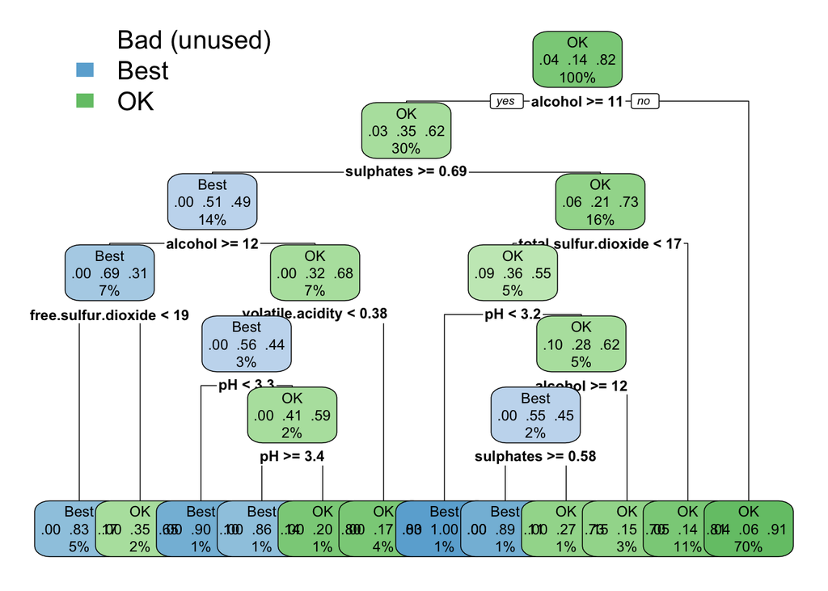

```r
tm <- rpart(quality~., MyTrain, method = "class")
rpart.plot(tm, tweak = 1.6)
```

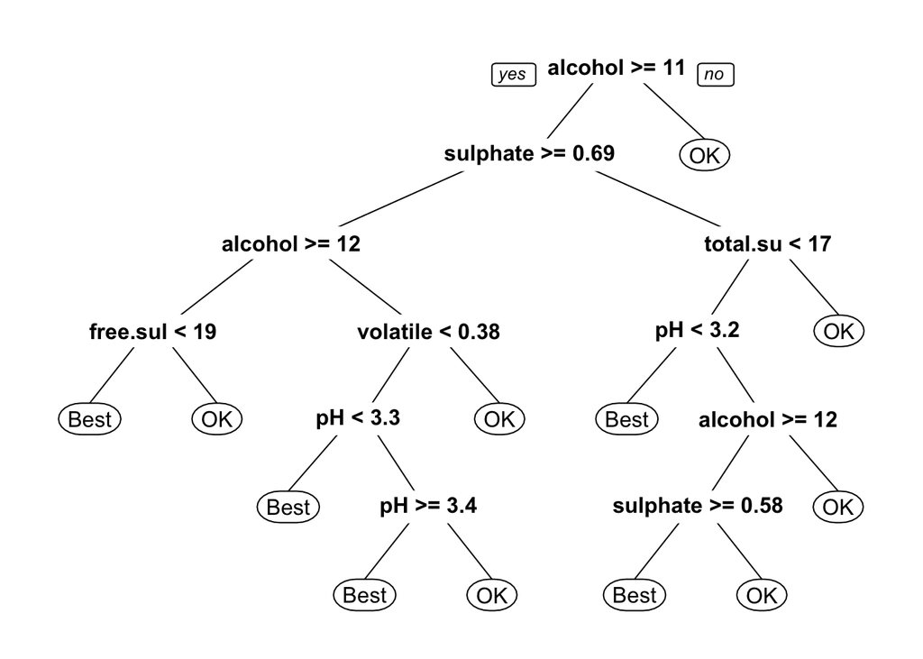

```r
prp(tm)
```

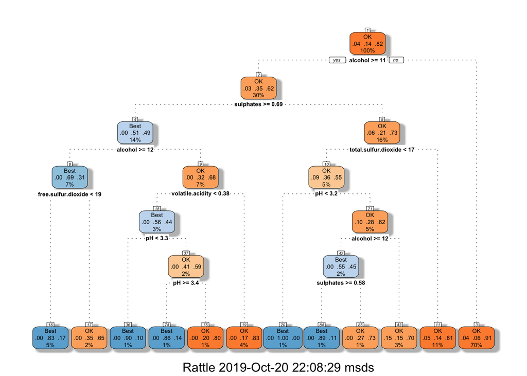

```r
fancyRpartPlot(tm)
```

### Prediction

```r
pred <- predict(tm, MyTest, type = "class")
table(MyTest$quality, pred)
```

```
##       pred
##        Bad Best  OK
##   Bad    0    0  16
##   Best   0   11  25
##   OK     0   10 258
```

##### Using our model, we now no prediction in order to classify the quality of wine.

### Confusion Matrix

```r
confusionMatrix(table(pred, MyTest$quality))
```

```
## Confusion Matrix and Statistics
##
##
## pred   Bad Best  OK
##   Bad    0    0   0
##   Best   0   11  10
##   OK    16   25 258
##
## Overall Statistics
##
##                Accuracy : 0.8406
##                  95% CI : (0.7958, 0.879)
##     No Information Rate : 0.8375
##     P-Value [Acc > NIR] : 0.4766
##
##                   Kappa : 0.2414
##
##  Mcnemar's Test P-Value : NA
##
## Statistics by Class:
##
##                      Class: Bad Class: Best Class: OK
## Sensitivity                0.00     0.30556    0.9627
## Specificity                1.00     0.96479    0.2115
## Pos Pred Value              NaN     0.52381    0.8629
## Neg Pred Value             0.95     0.91639    0.5238
## Prevalence                 0.05     0.11250    0.8375
## Detection Rate             0.00     0.03438    0.8063
## Detection Prevalence       0.00     0.06563    0.9344
## Balanced Accuracy          0.50     0.63517    0.5871
```

### Random Forest

##### Now using the same train and test data, lets use Random Forest classification.

```r
tm <- randomForest(quality~., data = MyTrain, importance = TRUE)
```

##### Prediction

```r
pred <- predict(tm, MyTest, type = "class")
table(MyTest$quality, pred)
```

```
##       pred
##        Bad Best  OK
##   Bad    0    0  16
##   Best   0   20  16
##   OK     0    8 260
```

### Confusion Matrix

```r
confusionMatrix(table(pred, MyTest$quality))
```

```
## Confusion Matrix and Statistics
##
##
## pred   Bad Best  OK
##   Bad    0    0   0
##   Best   0   20   8
##   OK    16   16 260
##
## Overall Statistics
##
##                Accuracy : 0.875
##                  95% CI : (0.8337, 0.9092)
##     No Information Rate : 0.8375
##     P-Value [Acc > NIR] : 0.03736
##
##                   Kappa : 0.4467
##
##  Mcnemar's Test P-Value : NA
##
## Statistics by Class:
##
##                      Class: Bad Class: Best Class: OK
## Sensitivity                0.00      0.5556    0.9701
## Specificity                1.00      0.9718    0.3846
## Pos Pred Value              NaN      0.7143    0.8904
## Neg Pred Value             0.95      0.9452    0.7143
## Prevalence                 0.05      0.1125    0.8375
## Detection Rate             0.00      0.0625    0.8125
## Detection Prevalence       0.00      0.0875    0.9125
## Balanced Accuracy          0.50      0.7637    0.6774
```

##### Here, our random forest predicts with an approximately 88% of accuracy which made our model better.

# Conclusion

##### Decision trees and Random Forests are classifiers that we had used for this assignment. Given this dataset, random forest predicted with more accuracy than a decision tree model. Given these curcumstances, it would be plausible to suggest to use random forest model in order to predict the quality of wines if the dataset comes with the same variables.

# References

https://www.r-bloggers.com/predicting-wine-quality-using-random-forests/  
https://rstudio-pubs-static.s3.amazonaws.com/318409_f3e4e00fb69f4e22b82c0e0f1f6014df.html